# Novel PacBio isoform analysis

Author

Project

Published

July 30, 2026

## 1 Scope

This report summarizes **novel (PacBio / `PB*`) isoforms** relative to known transcripts across all configured datasets, then contrasts novelty patterns between the **HT** and **UT** reference transcriptomes.

Novel isoforms are tagged when `oId` starts with the configured prefix (`PB` by default).

**ImportantInputs are already reduced to switching genes**

All 4 of 4 input ISA objects contain **only genes that already pass the gene-level q cutoff** (saved after `isoformSwitchTestDEXSeq(reduceToSwitchingGenes = TRUE)`).

Consequences for everything below: gene counts are *genes retained*, not *genes tested*; “present in the other dataset” means *retained in that saved object*, not *tested and non-significant*; and any percentage of genes has a denominator that was already selected on the outcome. Overlap between datasets is bounded by how many symbols survive in both objects. No enrichment test against this background is reported. See `docs/REVIEW_CHANGES.md`.

## 2 Dataset panel

### 2.1 Summary table

Novel isoform summary by dataset

| dataset_label | n_isoforms | n_novel_isoforms | pct_novel_isoforms | n_switching_isoforms | n_novel_switching_isoforms | pct_switching_that_are_novel | median_abs_dIF_novel | median_abs_dIF_known | median_abs_dIF_novel_switching | median_abs_dIF_known_switching | isoform_q_cutoff | gene_q_cutoff | min_abs_dif_cutoff | reference_transcriptome |
| --- | --- | --- | --- | --- | --- | --- | --- | --- | --- | --- | --- | --- | --- | --- |
| H_HT_supplementary | 128491 | 46550 | 36.23 | 192 | 112 | 58.33 | 0.01 | 0 | 0.19 | 0.20 | 0.05 | 0.05 | 0.15 | HT |
| T_HT_anchor | 148951 | 49794 | 33.43 | 125 | 57 | 45.60 | 0.01 | 0 | 0.19 | 0.18 | 0.05 | 0.05 | 0.15 | HT |
| T_UT | 166394 | 65637 | 39.45 | 143 | 71 | 49.65 | 0.01 | 0 | 0.19 | 0.18 | 0.05 | 0.05 | 0.15 | UT |
| U_UT | 173016 | 66761 | 38.59 | 79 | 39 | 49.37 | 0.01 | 0 | 0.20 | 0.20 | 0.05 | 0.05 | 0.15 | UT |

### 2.2 Overview figures

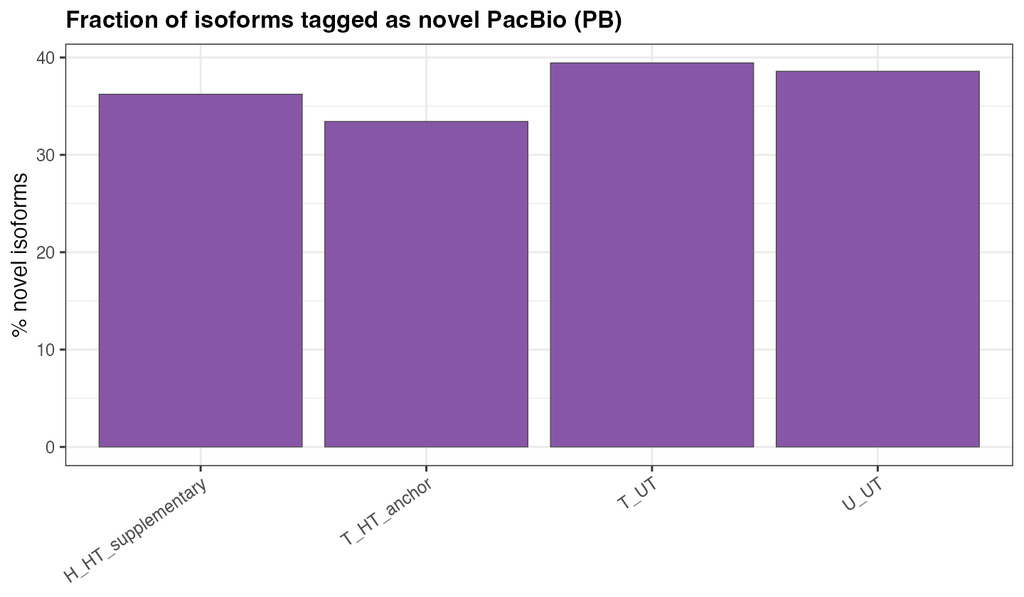

Fraction of isoforms tagged novel PacBio

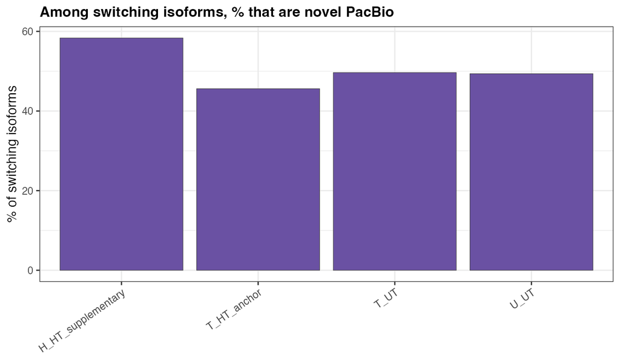

Among switching isoforms, percent that are novel

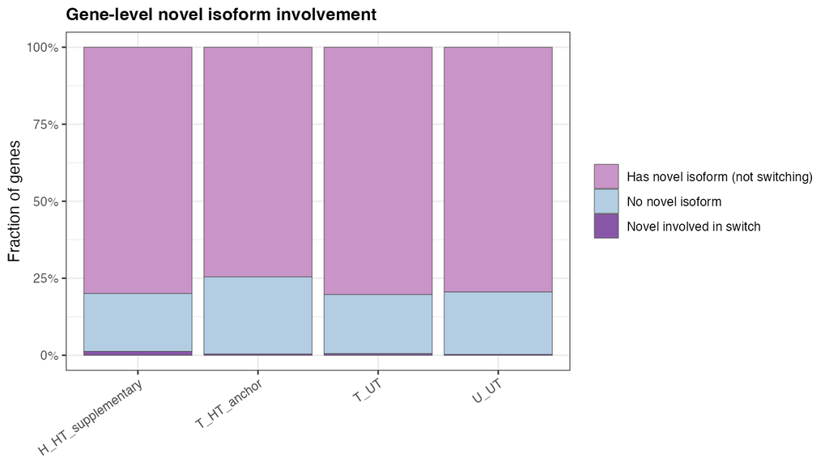

Gene-level novel involvement fractions

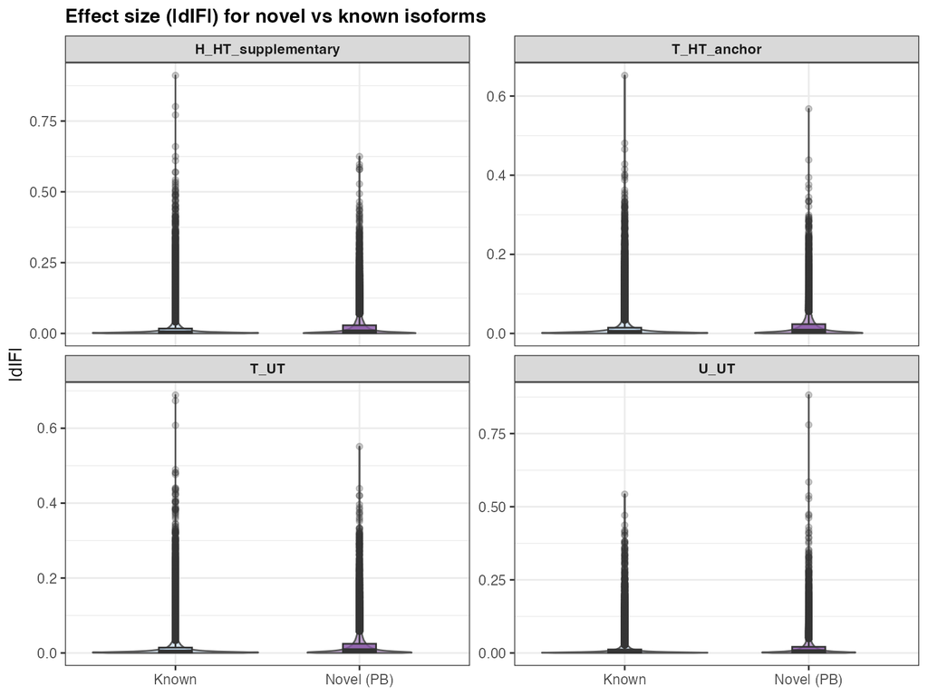

|dIF| for novel vs known isoforms

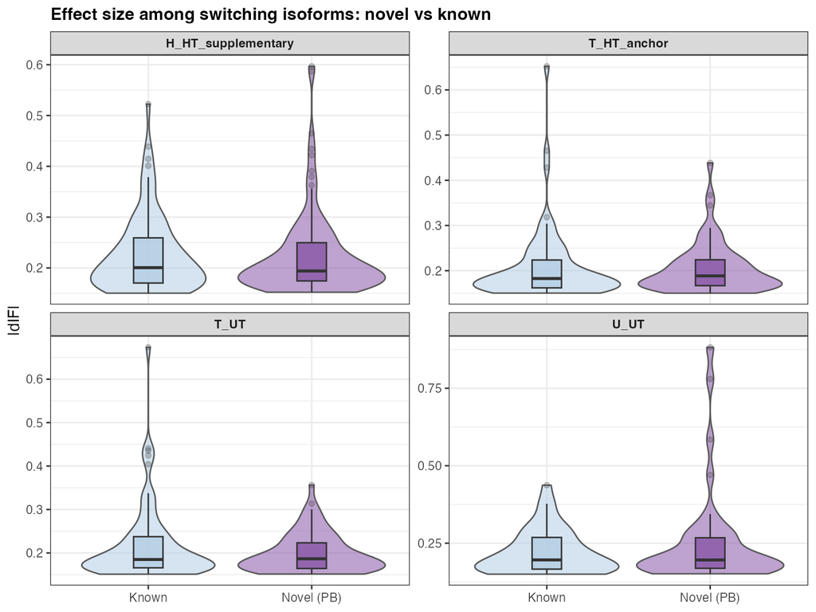

|dIF| among switching isoforms: novel vs known

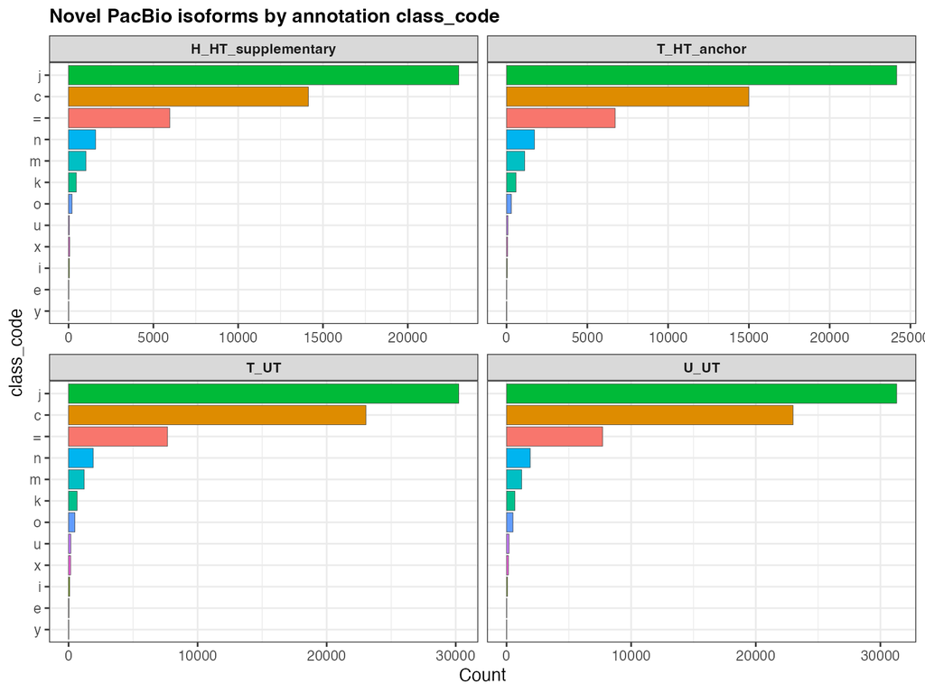

Novel isoforms by annotation class_code

## 3 Top novel switching events

### 3.1 Top novel switching genes (top 15 per dataset)

Top novel-involved switching genes

| dataset_label | rank | gene_name | gene_id | n_novel_switching_isoforms | max_abs_dif_novel_switching | min_novel_switch_q |
| --- | --- | --- | --- | --- | --- | --- |
| H_HT_supplementary | 1 | SLX1B | XLOC_019531 | 1 | 0.5968 | 0.0013 |
| H_HT_supplementary | 2 | GPC3 | XLOC_056732 | 1 | 0.5869 | 0.0000 |
| H_HT_supplementary | 3 | RABGAP1L | XLOC_001925 | 2 | 0.4648 | 0.0000 |
| H_HT_supplementary | 4 | IER2 | XLOC_025784 | 1 | 0.4344 | 0.0000 |
| H_HT_supplementary | 5 | TRIM13 | XLOC_013822 | 1 | 0.4219 | 0.0000 |
| H_HT_supplementary | 6 | SSTR2 | XLOC_022602 | 2 | 0.3909 | 0.0003 |
| H_HT_supplementary | 7 | RHNO1 | XLOC_010685 | 1 | 0.3792 | 0.0000 |
| H_HT_supplementary | 8 | IFITM2 | XLOC_007508 | 1 | 0.3630 | 0.0000 |
| H_HT_supplementary | 9 | MSH6 | XLOC_028473 | 1 | 0.3562 | 0.0000 |
| H_HT_supplementary | 10 | CMPK2 | XLOC_030175 | 2 | 0.3369 | 0.0000 |
| H_HT_supplementary | 11 | MBIP | XLOC_016209 | 1 | 0.3144 | 0.0120 |
| H_HT_supplementary | 12 | USP10 | XLOC_020178 | 1 | 0.3015 | 0.0000 |
| H_HT_supplementary | 13 | ZP3 | XLOC_047802 | 1 | 0.3006 | 0.0353 |
| H_HT_supplementary | 14 | TNFAIP1 | XLOC_021883 | 2 | 0.2987 | 0.0004 |
| H_HT_supplementary | 15 | CKS1B | XLOC_001633 | 1 | 0.2821 | 0.0000 |
| T_HT_anchor | 1 | THAP2 | XLOC_011473 | 1 | 0.4385 | 0.0000 |
| T_HT_anchor | 2 | RSAD2 | XLOC_028123 | 2 | 0.3671 | 0.0000 |
| T_HT_anchor | 3 | CD86 | XLOC_036495 | 1 | 0.3443 | 0.0000 |
| T_HT_anchor | 4 | RUBCN | XLOC_038662 | 1 | 0.2947 | 0.0000 |
| T_HT_anchor | 5 | IFITM2 | XLOC_007508 | 1 | 0.2890 | 0.0000 |
| T_HT_anchor | 6 | DDX58 | XLOC_053671 | 2 | 0.2820 | 0.0000 |
| T_HT_anchor | 7 | IFIT1 | XLOC_005992 | 1 | 0.2691 | 0.0000 |
| T_HT_anchor | 8 | IL23A | XLOC_011323 | 1 | 0.2664 | 0.0000 |
| T_HT_anchor | 9 | PLA2G7 | XLOC_046278 | 1 | 0.2557 | 0.0167 |
| T_HT_anchor | 10 | LCMT1 | XLOC_019483 | 1 | 0.2423 | 0.0003 |
| T_HT_anchor | 11 | GBP1 | XLOC_003699 | 1 | 0.2393 | 0.0072 |
| T_HT_anchor | 12 | CCL3 | XLOC_023406 | 2 | 0.2347 | 0.0000 |
| T_HT_anchor | 13 | CCDC117 | XLOC_034711 | 1 | 0.2333 | 0.0390 |
| T_HT_anchor | 14 | COG4 | XLOC_021196 | 1 | 0.2253 | 0.0000 |
| T_HT_anchor | 15 | IPCEF1 | XLOC_046969 | 4 | 0.2238 | 0.0000 |
| T_UT | 1 | CCL22 | XLOC_020026 | 2 | 0.3563 | 0.0007 |
| T_UT | 2 | IL23A | XLOC_011393 | 2 | 0.3136 | 0.0000 |
| T_UT | 3 | CD86 | XLOC_036709 | 2 | 0.3002 | 0.0000 |
| T_UT | 4 | IFITM2 | XLOC_007559 | 1 | 0.2895 | 0.0000 |
| T_UT | 5 | DDX58 | XLOC_054002 | 2 | 0.2854 | 0.0000 |
| T_UT | 6 | TFPI2 | XLOC_049673 | 1 | 0.2711 | 0.0000 |
| T_UT | 7 | TIMP3 | XLOC_034994 | 2 | 0.2691 | 0.0000 |
| T_UT | 8 | MRPL39 | XLOC_034300 | 1 | 0.2652 | 0.0116 |
| T_UT | 9 | AMN1 | XLOC_012538 | 1 | 0.2507 | 0.0000 |
| T_UT | 10 | TMEM52B | XLOC_010885 | 1 | 0.2483 | 0.0410 |
| T_UT | 11 | TXNL4B | XLOC_021363 | 2 | 0.2466 | 0.0042 |
| T_UT | 12 | CCL3 | XLOC_023567 | 2 | 0.2360 | 0.0000 |
| T_UT | 13 | JDP2 | XLOC_015706 | 1 | 0.2357 | 0.0000 |
| T_UT | 14 | NEMP1 | XLOC_012880 | 1 | 0.2351 | 0.0002 |
| T_UT | 15 | ZP3 | XLOC_048112 | 1 | 0.2282 | 0.0001 |
| U_UT | 1 | CCL22 | XLOC_020026 | 2 | 0.8822 | 0.0000 |
| U_UT | 2 | IL23A | XLOC_011393 | 2 | 0.5845 | 0.0000 |
| U_UT | 3 | CCL1 | XLOC_023526 | 1 | 0.4704 | 0.0001 |
| U_UT | 4 | TNFSF4 | XLOC_004551 | 1 | 0.3440 | 0.0000 |
| U_UT | 5 | CCL4 | XLOC_022194 | 2 | 0.3175 | 0.0000 |
| U_UT | 6 | CCL3 | XLOC_023567 | 2 | 0.2928 | 0.0000 |
| U_UT | 7 | TPMT | XLOC_046117 | 1 | 0.2813 | 0.0001 |
| U_UT | 8 | CHST10 | XLOC_031217 | 1 | 0.2679 | 0.0384 |
| U_UT | 9 | CD72 | XLOC_054071 | 1 | 0.2671 | 0.0002 |
| U_UT | 10 | PELO | XLOC_041899 | 1 | 0.2658 | 0.0000 |
| U_UT | 11 | TRIM38 | XLOC_044683 | 1 | 0.2205 | 0.0061 |
| U_UT | 12 | XLOC_003850 | XLOC_003850 | 2 | 0.2067 | 0.0113 |
| U_UT | 13 | SNX10 | XLOC_047626 | 1 | 0.2052 | 0.0005 |
| U_UT | 14 | SLC29A3 | XLOC_005858 | 1 | 0.2036 | 0.0004 |
| U_UT | 15 | XLOC_022235 | XLOC_022235 | 1 | 0.2021 | 0.0018 |

### 3.2 Top novel switching isoforms (top 10 per dataset)

Top novel switching isoforms

| dataset_label | gene_name | isoform_id | oId | class_code | dIF | abs_dIF | isoform_switch_q |
| --- | --- | --- | --- | --- | --- | --- | --- |
| H_HT_supplementary | SLX1B | TCONS_00112614 | PB.3741.1 | c | 0.5968 | 0.5968 | 0.0013 |
| H_HT_supplementary | GPC3 | TCONS_00294656 | PB.10168.1 | j | 0.5869 | 0.5869 | 0.0000 |
| H_HT_supplementary | RABGAP1L | TCONS_00008449 | PB.844.1 | = | 0.4648 | 0.4648 | 0.0000 |
| H_HT_supplementary | IER2 | TCONS_00150814 | PB.6237.1 | c | -0.4344 | 0.4344 | 0.0000 |
| H_HT_supplementary | TRIM13 | TCONS_00074716 | PB.2861.1 | = | 0.4219 | 0.4219 | 0.0000 |
| H_HT_supplementary | SSTR2 | TCONS_00128623 | PB.4449.1 | j | 0.3909 | 0.3909 | 0.0003 |
| H_HT_supplementary | RHNO1 | TCONS_00070434 | PB.2142.4 | c | -0.3792 | 0.3792 | 0.0000 |
| H_HT_supplementary | IFITM2 | TCONS_00039729 | PB.1537.1 | = | 0.3630 | 0.3630 | 0.0000 |
| H_HT_supplementary | MSH6 | TCONS_00172855 | PB.6881.3 | j | 0.3562 | 0.3562 | 0.0000 |
| H_HT_supplementary | CMPK2 | TCONS_00173271 | PB.6680.3 | c | 0.3369 | 0.3369 | 0.0000 |
| T_HT_anchor | THAP2 | TCONS_00061300 | PB.2450.1 | = | 0.4385 | 0.4385 | 0.0000 |
| T_HT_anchor | RSAD2 | TCONS_00151268 | PB.5145.32 | = | 0.3671 | 0.3671 | 0.0000 |
| T_HT_anchor | CD86 | TCONS_00194764 | PB.8933.2 | = | 0.3443 | 0.3443 | 0.0000 |
| T_HT_anchor | RUBCN | TCONS_00207289 | PB.7167.5 | k | -0.2947 | 0.2947 | 0.0000 |
| T_HT_anchor | IFITM2 | TCONS_00039729 | PB.1537.1 | = | 0.2890 | 0.2890 | 0.0000 |
| T_HT_anchor | DDX58 | TCONS_00285540 | PB.16261.1 | c | -0.2820 | 0.2820 | 0.0000 |
| T_HT_anchor | IFIT1 | TCONS_00038546 | PB.1367.199 | j | 0.2691 | 0.2691 | 0.0000 |
| T_HT_anchor | IL23A | TCONS_00060450 | PB.2384.1 | = | 0.2664 | 0.2664 | 0.0000 |
| T_HT_anchor | PLA2G7 | TCONS_00247239 | PB.8546.20 | c | -0.2557 | 0.2557 | 0.0167 |
| T_HT_anchor | LCMT1 | TCONS_00112926 | PB.6197.5 | j | -0.2423 | 0.2423 | 0.0003 |
| T_UT | CCL22 | TCONS_00111382 | PB.4996.2 | = | 0.3563 | 0.3563 | 0.0009 |
| T_UT | IL23A | TCONS_00064570 | PB.4584.2 | = | 0.3136 | 0.3136 | 0.0000 |
| T_UT | CD86 | TCONS_00221290 | PB.13265.3 | c | 0.3002 | 0.3002 | 0.0000 |
| T_UT | IFITM2 | TCONS_00042948 | PB.3070.1 | = | 0.2895 | 0.2895 | 0.0000 |
| T_UT | DDX58 | TCONS_00302251 | PB.16261.1 | c | -0.2854 | 0.2854 | 0.0000 |
| T_UT | TFPI2 | TCONS_00274354 | PB.11657.2 | = | 0.2711 | 0.2711 | 0.0000 |
| T_UT | TIMP3 | TCONS_00200962 | PB.10677.3 | c | 0.2691 | 0.2691 | 0.0000 |
| T_UT | MRPL39 | TCONS_00193877 | PB.11909.1 | = | -0.2652 | 0.2652 | 0.0116 |
| T_UT | TIMP3 | TCONS_00200963 | PB.10677.6 | c | -0.2531 | 0.2531 | 0.0000 |
| T_UT | AMN1 | TCONS_00077391 | PB.4058.7 | c | 0.2507 | 0.2507 | 0.0000 |
| U_UT | CCL22 | TCONS_00111382 | PB.4996.2 | = | 0.8822 | 0.8822 | 0.0000 |
| U_UT | CCL22 | TCONS_00119223 | PB.6379.3 | j | -0.7800 | 0.7800 | 0.0000 |
| U_UT | IL23A | TCONS_00064570 | PB.4584.2 | = | 0.5845 | 0.5845 | 0.0000 |
| U_UT | CCL1 | TCONS_00130534 | PB.5407.1 | = | 0.4704 | 0.4704 | 0.0001 |
| U_UT | TNFSF4 | TCONS_00018922 | PB.1538.5 | = | 0.3440 | 0.3440 | 0.0000 |
| U_UT | CCL4 | TCONS_00123817 | PB.5430.1 | = | -0.3175 | 0.3175 | 0.0000 |
| U_UT | CCL3 | TCONS_00130722 | PB.5431.20 | = | 0.2928 | 0.2928 | 0.0000 |
| U_UT | TPMT | TCONS_00261996 | PB.13586.2 | j | -0.2813 | 0.2813 | 0.0001 |
| U_UT | CCL4 | TCONS_00123834 | PB.5430.21 | = | 0.2781 | 0.2781 | 0.0000 |
| U_UT | CHST10 | TCONS_00179824 | PB.9211.1 | c | -0.2679 | 0.2679 | 0.0384 |

## 4 HT vs UT contrast panel

This panel aggregates datasets by `reference_transcriptome` (HT vs UT) and compares novelty burden, then asks which **gene symbols** with novel involvement appear in both references.

### 4.1 Aggregated HT vs UT rates

HT vs UT novelty summary

| reference_transcriptome | n_datasets | n_isoforms | n_novel_isoforms | pct_novel_isoforms | n_switching_isoforms | n_novel_switching_isoforms | pct_switching_that_are_novel |
| --- | --- | --- | --- | --- | --- | --- | --- |
| HT | 2 | 277442 | 96344 | 34.73 | 317 | 169 | 53.31 |
| UT | 2 | 339410 | 132398 | 39.01 | 222 | 110 | 49.55 |

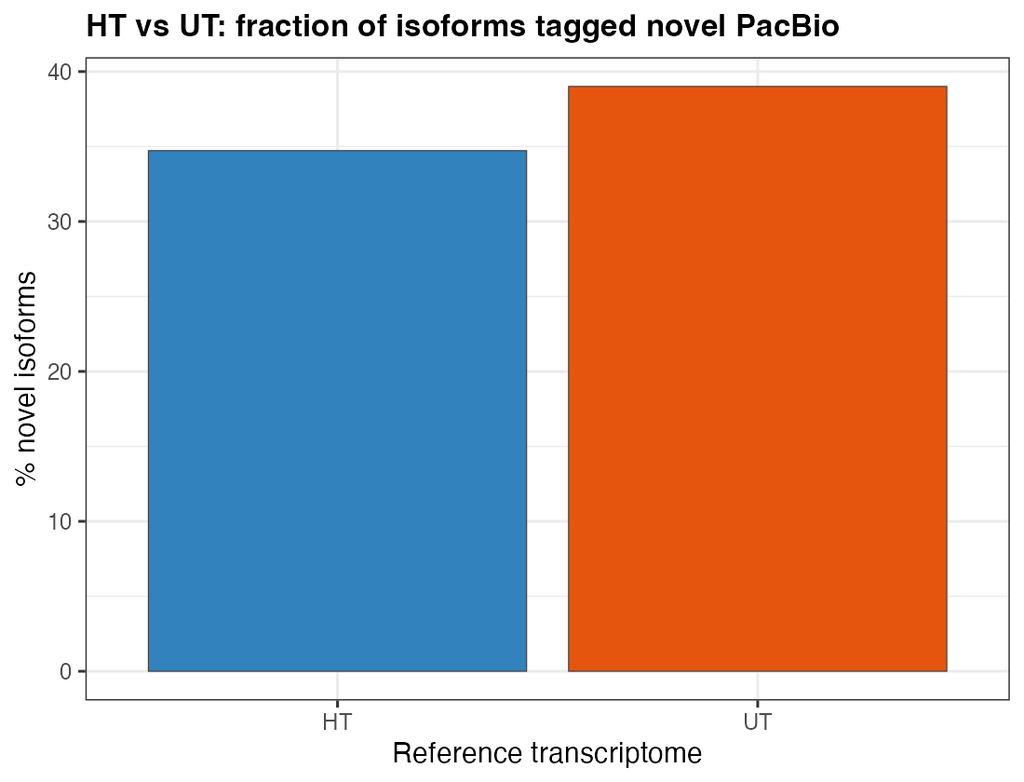

HT vs UT percent novel isoforms

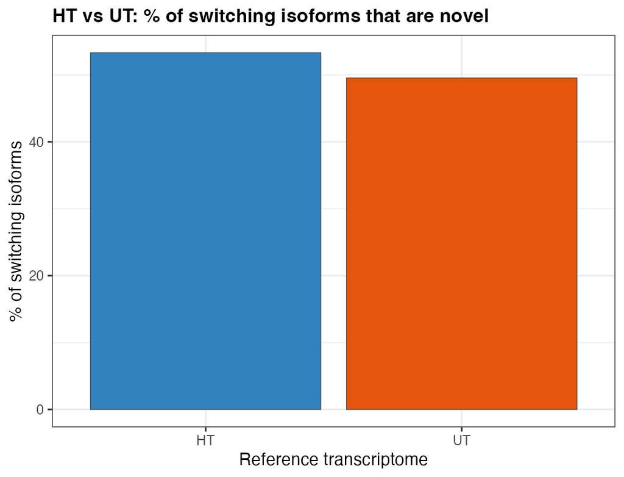

HT vs UT percent novel among switching isoforms

### 4.2 Novel-involved gene-symbol overlap

Overlap of novel-involved gene symbols (HT vs UT)

| n_novel_involved_genes_HT | n_novel_involved_genes_UT | n_shared_gene_names | n_HT_only | n_UT_only | n_symbols_present_in_both_references | overlap_is_bounded_by_object_retention |
| --- | --- | --- | --- | --- | --- | --- |
| 143 | 82 | 23 | 120 | 59 | 23 | TRUE |

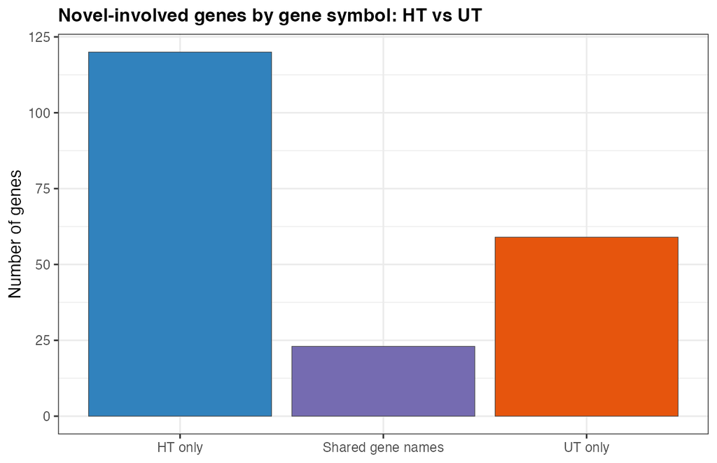

Shared vs reference-specific novel-involved genes

### 4.3 Shared novel-involved genes (top by HT effect size)

Shared novel-involved gene symbols across HT and UT (first 40)

| gene_name | n_datasets_HT | max_abs_dif_novel_switching_HT | max_n_novel_switching_HT | n_datasets_UT | max_abs_dif_novel_switching_UT | max_n_novel_switching_UT |
| --- | --- | --- | --- | --- | --- | --- |
| IFITM2 | 2 | 0.3630 | 1 | 1 | 0.2895 | 1 |
| CD86 | 1 | 0.3443 | 1 | 1 | 0.3002 | 2 |
| ZP3 | 2 | 0.3006 | 1 | 1 | 0.2282 | 1 |
| DDX58 | 1 | 0.2820 | 2 | 1 | 0.2854 | 2 |
| IL23A | 1 | 0.2664 | 1 | 2 | 0.5845 | 2 |
| MERTK | 2 | 0.2635 | 1 | 1 | 0.1729 | 1 |
| GBP1 | 1 | 0.2393 | 1 | 1 | 0.1851 | 1 |
| CCL3 | 1 | 0.2347 | 2 | 2 | 0.2928 | 2 |
| IPCEF1 | 1 | 0.2238 | 4 | 1 | 0.2028 | 3 |
| JDP2 | 1 | 0.2092 | 1 | 1 | 0.2357 | 1 |
| NEMP1 | 1 | 0.2042 | 1 | 1 | 0.2351 | 1 |
| TMIGD3 | 1 | 0.1939 | 1 | 1 | 0.1529 | 1 |
| TMEM170B | 1 | 0.1927 | 1 | 1 | 0.2086 | 1 |
| CCL4 | 1 | 0.1885 | 2 | 2 | 0.3175 | 2 |
| CLEC4G | 1 | 0.1772 | 1 | 1 | 0.1603 | 1 |
| PYM1 | 1 | 0.1771 | 1 | 1 | 0.1764 | 1 |
| ACP3 | 1 | 0.1734 | 1 | 1 | 0.1536 | 1 |
| USP18 | 2 | 0.1731 | 1 | 1 | 0.1656 | 1 |
| EVI2B | 1 | 0.1712 | 1 | 1 | 0.1533 | 1 |
| SYNJ2 | 1 | 0.1659 | 1 | 1 | 0.1803 | 1 |
| PCSK7 | 1 | 0.1646 | 1 | 1 | 0.1571 | 1 |
| FSD1L | 1 | 0.1601 | 1 | 1 | 0.1978 | 1 |
| RAB7B | 1 | 0.1540 | 1 | 1 | 0.1741 | 2 |

## 5 Notes

- Overlap uses **gene symbols**, because `XLOC_*` / ISA gene IDs are transcriptome-specific.
- “Novel involved” means at least one significant switching isoform is tagged PacBio novel under config q / |dIF| cutoffs.
- Rebuild with:

```bash
Rscript scripts/03_novel_isoform_analysis.R
quarto render reports/novel_isoform_analysis.qmd
```